# SECR - stoat

```r
library(dplyr)
library(secr)
```

# Dati

```r
summary(stoatCH)
```

```
Object class       capthist
Detector type      multi
Detector number    94
Average spacing    250 m
x-range            -1500 1500 m
y-range            -1500 1500 m

Counts by occasion
```

|  | 1 | 2 | 3 | 4 | 5 | 6 | 7 | Total |
| --- | --- | --- | --- | --- | --- | --- | --- | --- |
| n | 3 | 4 | 8 | 3 | 3 | 7 | 2 | 30 |
| u | 3 | 3 | 8 | 2 | 0 | 3 | 1 | 20 |
| f | 12 | 6 | 2 | 0 | 0 | 0 | 0 | 20 |
| M(t+1) | 3 | 6 | 14 | 16 | 16 | 19 | 20 | 20 |
| losses | 0 | 0 | 0 | 0 | 0 | 0 | 0 | 0 |
| detections | 3 | 4 | 8 | 3 | 3 | 7 | 2 | 30 |
| detectors visited | 3 | 4 | 8 | 3 | 3 | 7 | 2 | 30 |
| detectors used | 94 | 94 | 94 | 94 | 94 | 94 | 94 | 658 |

Plot dei dati spaziali, con spezzata che unisce la catture consecutive di uno stesso individuo:

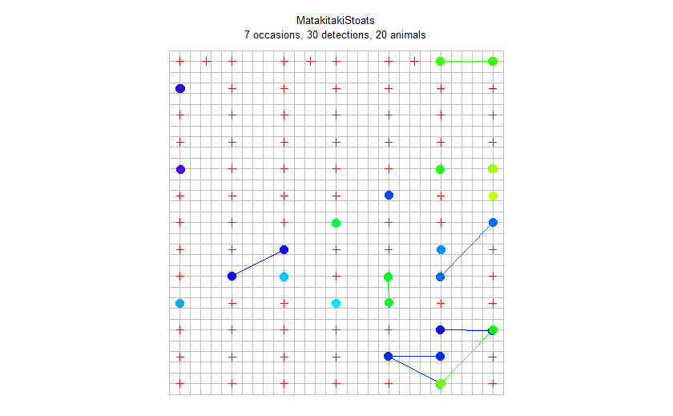

```r
par(mar = c(1,1,3,1)) # riduce i margini, param grafico
plot(stoatCH, tracks = TRUE)
```

Scala spaziale (sigma) - prima stima:

```r
initialsigma <- RPSV(stoatCH, CC = TRUE)
cat("Quick and biased estimate of sigma =", initialsigma, "m\n")
```

```
Quick and biased estimate of sigma = 243.6699 m
```

La scala spaziale ci serve per definire un buffer attorno alle nostre trappole - il buffer serve a definire l’area che viene usata per stimare la densità, e deve essere abbastanza ampio affinche gli animali che sono al bordo dell’area abbiano una probabilità pari a 0 di finire nel nostro campione. Di norma, 4 per sigma è una distanza sufficiente (perché stiamo adottando una distribuzione *half-normal*, e questa soglia è definita su base empirica)

```r
detector(traps(stoatCH)) <- "multi"
setNumThreads(2)    # number of cores to use
```

```
[1] 2
```

```r
fit.hn <- secr.fit(stoatCH, buffer = 4 * initialsigma, trace = FALSE, detectfn = 0)
fit.hn
```

```
secr.fit(capthist = stoatCH, buffer = 4 * initialsigma, detectfn = 0,
    trace = FALSE)
secr 4.6.6, 20:45:51 12 mar 2024

Detector type      multi
Detector number    94
Average spacing    250 m
x-range            -1500 1500 m
y-range            -1500 1500 m

N animals       :  20
N detections    :  30
N occasions     :  7
Mask area       :  2368.28 ha

Model           :  D~1 g0~1 sigma~1
Fixed (real)    :  none
Detection fn    :  halfnormal
Distribution    :  poisson
N parameters    :  3
Log likelihood  :  -144.0014
AIC             :  294.0028
AICc            :  295.5028

Beta parameters (coefficients)
```

|  | beta | SE.beta | lcl | ucl |
| --- | --- | --- | --- | --- |
| D | -3.800334 | 0.2865657 | -4.361993 | -3.238675 |
| g0 | -2.914091 | 0.4446751 | -3.785639 | -2.042544 |
| sigma | 5.552674 | 0.1722522 | 5.215066 | 5.890282 |

```
Variance-covariance matrix of beta parameters
                 D          g0        sigma
D      0.082119922 -0.04109013 -0.007140052
g0    -0.041090134  0.19773592 -0.054720083
sigma -0.007140052 -0.05472008  0.029670824

Fitted (real) parameters evaluated at base levels of covariates
```

|  | link | estimate | SE.estimate | lcl | ucl |
| --- | --- | --- | --- | --- | --- |
| D | log | 0.02236330 | 0.006542402 | 0.01275295 | 0.0392158 |
| g0 | logit | 0.05146135 | 0.021705960 | 0.02219076 | 0.1148079 |
| sigma | log | 257.92626979 | 44.759972585 | 184.02390024 | 361.5071768 |

```
NA
```

```r
# confint(fit.hn, "D")
```

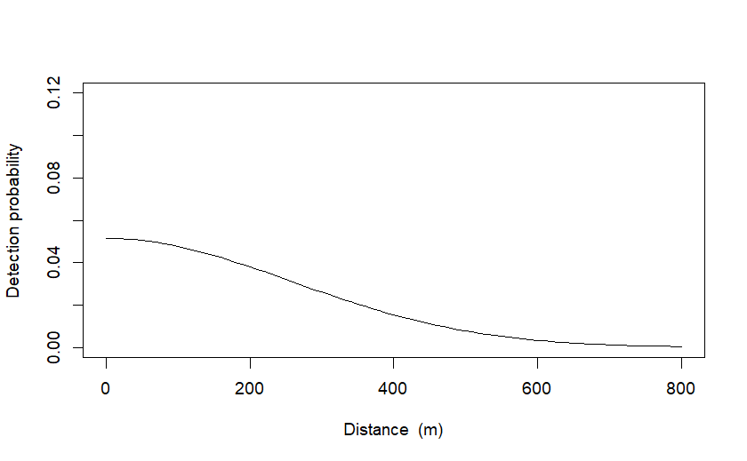

```r
xv <- seq(0,800,10)
plot(fit.hn, xval = xv, ylim = c(0,0.12), limits = FALSE, lty = 1)
```

# Verifica sul valore del buffer

Come detto sopra, il valore di sigma iniziale serve a definire il buffer per la stima della densità. Verifichiamo che esso vada bene con il seguente plot:

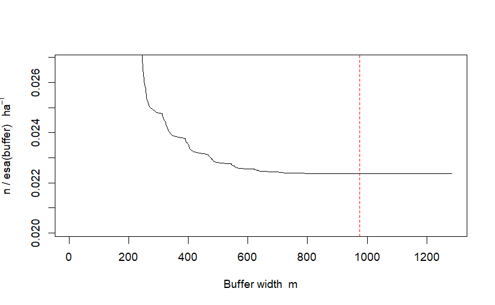

```r
esa.plot(fit.hn)
abline(v = 4 * initialsigma, lty = 2, col = 'red')
```

che ci dice che alla distanza scelta per il buffer (indicata dalla linea tratteggiata rossa), la stima della densità ha già raggiunto un asintoto (cioè non cambia più al variare della distanza)

# Approfondimento sulla detection function

Nel modello che abbiamo appena fittato, abbiamo assunto che la probabilità di avvistare un animale diminuisca con la distanza secondo un modello *half-normal*, ma possono essere applicati altri modelli, i più comuni sono *negative exponential* e *hazard rate*

```r
fit.HN <- secr.fit(stoatCH, buffer = 4 * initialsigma, detectfn = 'HN', trace = FALSE)
fit.EX <- secr.fit(stoatCH, buffer = 4 * initialsigma, detectfn = 'EX', trace = FALSE)
fit.HR <- secr.fit(stoatCH, buffer = 4 * initialsigma, detectfn = 'HR', trace = FALSE)
```

```
Avvertimento: at least one variance calculation failed
```

```r
fits <- secrlist(HN = fit.HN, EX = fit.EX, HR = fit.HR)
predict(fits)
```

|  | link | estimate | SE.estimate | lcl | ucl |
| --- | --- | --- | --- | --- | --- |
| D | log | 0.02236330 | 0.006542403 | 0.01275295 | 0.03921581 |
| g0 | logit | 0.05146137 | 0.021705923 | 0.02219081 | 0.11480776 |
| sigma | log | 257.92618302 | 44.759905392 | 184.02390963 | 361.50691515 |

|  | link | estimate | SE.estimate | lcl | ucl |
| --- | --- | --- | --- | --- | --- |
| D | log | 0.02231762 | 0.006617304 | 0.01263454 | 0.03942179 |
| g0 | logit | 0.12449302 | 0.059585061 | 0.04644069 | 0.29336817 |
| sigma | log | 166.18077082 | 36.019504656 | 109.19360577 | 252.90902703 |

|  | link | estimate | SE.estimate | lcl | ucl |
| --- | --- | --- | --- | --- | --- |
| D | log | 2.354275e-02 | 6.850875e-03 | 0.01346405 | 4.116597e-02 |
| g0 | logit | 2.873196e-02 | 8.529662e-03 | 0.01599020 | 5.109970e-02 |
| sigma | log | 4.734980e+02 | NaN | NaN | NaN |
| z | log | 9.632670e+04 | 1.360464e+19 | 0.01295828 | 7.160545e+11 |

```
NA
```

NB. confrontate soltanto i valori di D, perché sigma ha significato diverso a seconda dei modelli

```r
AIC(fits)
```

|  | model | detectfn | npar | logLik | AIC | AICc | dAICc | AICcwt |
| --- | --- | --- | --- | --- | --- | --- | --- | --- |
| HN | D~1 g0~1 sigma~1 | halfnormal | 3 | -144.0014 | 294.003 | 295.503 | 0.000 | 0.5131 |
| EX | D~1 g0~1 sigma~1 | exponential | 3 | -144.7010 | 295.402 | 296.902 | 1.399 | 0.2549 |
| HR | D~1 g0~1 sigma~1 z~1 | hazard rate | 4 | -143.2124 | 294.425 | 297.091 | 1.588 | 0.2319 |

```r
## plot fitted detection functions
xv <- seq(0,800,10)
plot(fit.EX, xval = xv, ylim = c(0,0.12), limits = FALSE,
    lty = 2)
plot(fit.HN, xval = xv, limits = FALSE, lty = 1, add = TRUE)
```

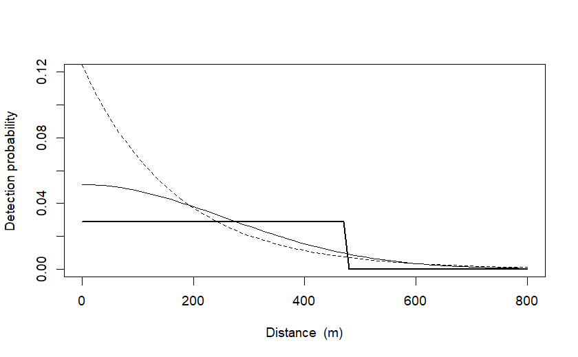

```r
plot(fit.HR, xval = xv, limits = FALSE, lty = 1, add = TRUE, lwd = 2)
```

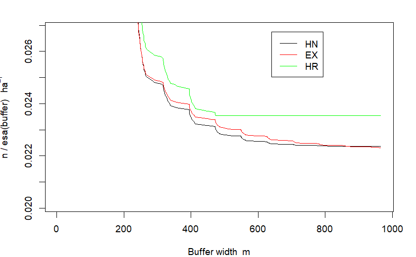

```r
par(mar = c(4,4,2,2))
esa.plot(fits, max.buffer = 4 * initialsigma)
```

In alternativa, possiamo anche fare un *model averaging* dei modelli:

```r
modelAverage(secrlist(HN = fit.HN, EX = fit.EX), criterion = "AICc")
```

```
          estimate  SE.estimate          lcl          ucl
D       0.02234813  0.006567449   0.01271335   0.03928459
g0      0.06950662  0.042762389   0.02003197   0.21443515
sigma 222.91066877 63.451974125 128.98475851 385.23285098
```

# Parametri del modello SECR

Nel modello di base, ogni parametro stimato è costante (D ~ 1, g0 ~ 1, sigma ~ 1), non dipende da altri parametri. Ma possiamo inserire dei predittori, o variabili esplicative, per ciascn parametro del modello SECR.

```r
fit.HNb <- secr.fit (stoatCH, buffer = 4 * initialsigma,
                     detectfn = 'HN',
                     model = g0 ~ b, trace = FALSE)
fit.HNbk <- secr.fit (stoatCH, buffer = 4 * initialsigma,
                      detectfn = 'HN',
                      model = g0 ~ bk, trace = FALSE)
fitsb <- secrlist(null = fits$HN, b = fit.HNb, bk = fit.HNbk)
AIC(fitsb)
```

|  | model | detectfn | npar | logLik | AIC | AICc | dAICc | AICcwt |
| --- | --- | --- | --- | --- | --- | --- | --- | --- |
| null | D~1 g0~1 sigma~1 | halfnormal | 3 | -144.0014 | 294.003 | 295.503 | 0.000 | 0.7019 |
| b | D~1 g0~b sigma~1 | halfnormal | 4 | -143.9362 | 295.872 | 298.539 | 3.036 | 0.1538 |
| bk | D~1 g0~bk sigma~1 | halfnormal | 4 | -144.0002 | 296.000 | 298.667 | 3.164 | 0.1443 |

```r
fit.HNb
```